# 24_flip_parabola

## 24_flip_parabola

#### Question

1. A downward-facing [parabola](https://en.wikipedia.org/wiki/Parabola) $f$ is defined below.

   $$f(x)~=~-x^{2}-{4}x-{9}$$

   An upwards-facing parabola, $g$, is constructed such that $g$ and $f$ are mirror images with a shared vertex, as shown in the graph below.

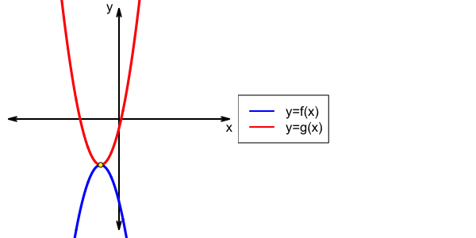

   The second parabola, $g$, can be written in standard form with two parameters ($B$ and $C$).

   $$g(x)~=~x^2+Bx+C$$

   Find $B$ and $C$.
   - $B~=~$
   - $C~=~$

#### Question

2. A downward-facing [parabola](https://en.wikipedia.org/wiki/Parabola) $f$ is defined below.

   $$f(x)~=~-x^{2}-{6}x-{2}$$

   An upwards-facing parabola, $g$, is constructed such that $g$ and $f$ are mirror images with a shared vertex, as shown in the graph below.

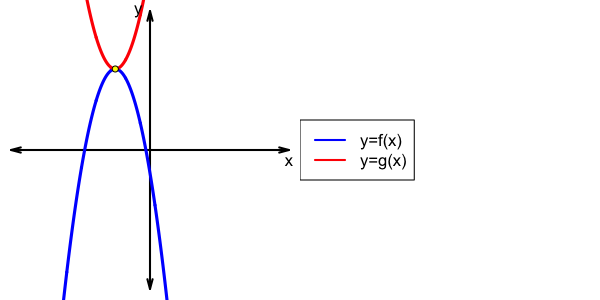

   The second parabola, $g$, can be written in standard form with two parameters ($B$ and $C$).

   $$g(x)~=~x^2+Bx+C$$

   Find $B$ and $C$.
   - $B~=~$
   - $C~=~$

#### Question

3. A downward-facing [parabola](https://en.wikipedia.org/wiki/Parabola) $f$ is defined below.

   $$f(x)~=~-x^{2}+{18}x-{88}$$

   An upwards-facing parabola, $g$, is constructed such that $g$ and $f$ are mirror images with a shared vertex, as shown in the graph below.

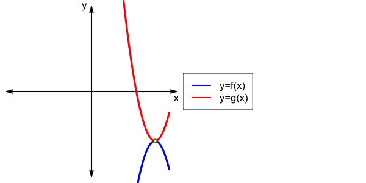

   The second parabola, $g$, can be written in standard form with two parameters ($B$ and $C$).

   $$g(x)~=~x^2+Bx+C$$

   Find $B$ and $C$.
   - $B~=~$
   - $C~=~$

#### Question

4. A downward-facing [parabola](https://en.wikipedia.org/wiki/Parabola) $f$ is defined below.

   $$f(x)~=~-x^{2}-{18}x-{79}$$

   An upwards-facing parabola, $g$, is constructed such that $g$ and $f$ are mirror images with a shared vertex, as shown in the graph below.

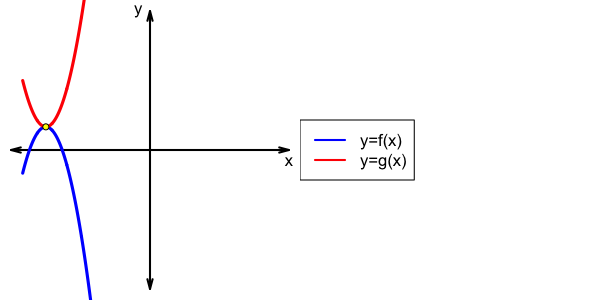

   The second parabola, $g$, can be written in standard form with two parameters ($B$ and $C$).

   $$g(x)~=~x^2+Bx+C$$

   Find $B$ and $C$.
   - $B~=~$
   - $C~=~$

#### Question

5. A downward-facing [parabola](https://en.wikipedia.org/wiki/Parabola) $f$ is defined below.

   $$f(x)~=~-x^{2}+{8}x-{25}$$

   An upwards-facing parabola, $g$, is constructed such that $g$ and $f$ are mirror images with a shared vertex, as shown in the graph below.

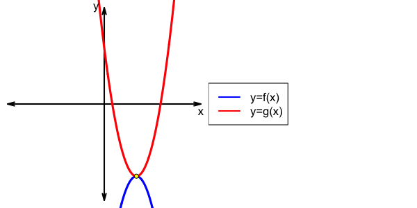

   The second parabola, $g$, can be written in standard form with two parameters ($B$ and $C$).

   $$g(x)~=~x^2+Bx+C$$

   Find $B$ and $C$.
   - $B~=~$
   - $C~=~$

#### Question

6. A downward-facing [parabola](https://en.wikipedia.org/wiki/Parabola) $f$ is defined below.

   $$f(x)~=~-x^{2}-{10}x-{27}$$

   An upwards-facing parabola, $g$, is constructed such that $g$ and $f$ are mirror images with a shared vertex, as shown in the graph below.

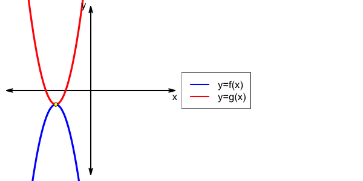

   The second parabola, $g$, can be written in standard form with two parameters ($B$ and $C$).

   $$g(x)~=~x^2+Bx+C$$

   Find $B$ and $C$.
   - $B~=~$
   - $C~=~$

#### Question

7. A downward-facing [parabola](https://en.wikipedia.org/wiki/Parabola) $f$ is defined below.

   $$f(x)~=~-x^{2}-{6}x-{13}$$

   An upwards-facing parabola, $g$, is constructed such that $g$ and $f$ are mirror images with a shared vertex, as shown in the graph below.

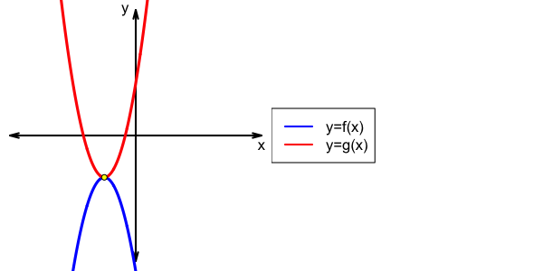

   The second parabola, $g$, can be written in standard form with two parameters ($B$ and $C$).

   $$g(x)~=~x^2+Bx+C$$

   Find $B$ and $C$.
   - $B~=~$
   - $C~=~$

#### Question

8. A downward-facing [parabola](https://en.wikipedia.org/wiki/Parabola) $f$ is defined below.

   $$f(x)~=~-x^{2}+{14}x-{54}$$

   An upwards-facing parabola, $g$, is constructed such that $g$ and $f$ are mirror images with a shared vertex, as shown in the graph below.

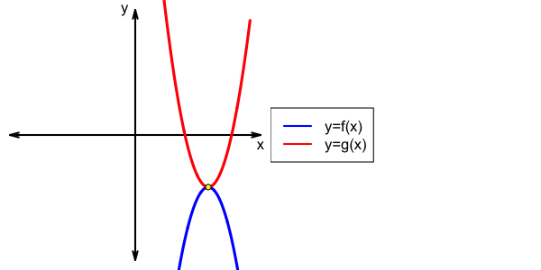

   The second parabola, $g$, can be written in standard form with two parameters ($B$ and $C$).

   $$g(x)~=~x^2+Bx+C$$

   Find $B$ and $C$.
   - $B~=~$
   - $C~=~$